# RNA-Seq_analysis_UCEC

Karolina Barbosa - PG55129; Elidiane do Rosário - PG55128, João Ferreira - PG52182

2025-04-07

# Introdução

O **Cancro** constitui uma das patologias mais complexas e desafiantes enfrentadas pela humanidade. Encontram-se identificados mais de 200 tipos distintos de cancro, cada um caracterizado por perfis moleculares específicos que exigem abordagens terapêuticas diferenciadas. Esta doença distingue-se por alterações genómicas dinâmicas, sendo que os padrões de anomalias genéticas — incluindo mutações somáticas, variações no número de cópias, alterações na expressão génica e múltiplas modificações epigenéticas — são únicos para cada tipo tumoral. Os avanços recentes nas tecnologias de sequenciação genómica de alto rendimento, conjugados com o progresso na bioinformática, têm ampliado significativamente o conhecimento sobre a biologia molecular do cancro <sup>1</sup>.

Neste contexto, destaca-se o contributo do consórcio *The Cancer Genome Atlas* (**TCGA**), que, ao longo de uma década, agregou dados clínicos, patológicos e perfis moleculares multi-ómicos relativos a mais de 11.000 tumores humanos, abrangendo 33 entidades neoplásicas distintas<sup>2</sup>. O carácter de acesso livre dos dados disponibilizados pelo TCGA reflete o compromisso desta iniciativa com a transparência científica e a partilha de conhecimento, tendo constituído um marco fundamental na compreensão da biologia tumoral e no desenvolvimento de novas estratégias terapêuticas, de diagnóstico e de prevenção.

Entre as neoplasias presentes no TCGA encontra-se o **Carcinoma Endometrial do Corpo do Útero** — frequentemente designado por Cancro Endometrial —, um tumor epitelial maligno que tem origem no endométrio, o revestimento interno do útero<sup>3</sup>.

Segundo dados da **Organização Mundial da Saúde (OMS)**, em 2020, o cancro do corpo do útero ocupava, a nível global, a 15.ª posição entre os tipos de cancro com maior incidência, com mais de 417.000 novos diagnósticos e 97.370 mortes atribuídas à doença. Em Portugal, foi a 13.ª neoplasia maligna mais incidente, com 1.238 novos casos e 361 óbitos registados nesse ano<sup>4</sup>.  
A maior prevalência desta neoplasia em países desenvolvidos está fortemente correlacionada com fatores como o envelhecimento populacional e o aumento da prevalência de obesidade e diabetes<sup>3,5</sup>. Embora ocorra predominantemente em mulheres pós-menopáusicas, estima-se que entre 15% e 25% dos casos afetem mulheres em idade reprodutiva, o que levanta desafios específicos no âmbito da preservação da fertilidade<sup>6</sup>. Não obstante os avanços verificados no diagnóstico precoce e nas modalidades terapêuticas, o cancro endometrial continua a representar um desafio significativo em saúde pública, em virtude do seu prognóstico heterogéneo, condicionado sobretudo pelo estádio clínico e pelo subtipo histológico ao momento do diagnóstico.

#### **Objetivo**

Face ao exposto, o presente trabalho tem como objetivo a análise do perfil transcriptómico de pacientes diagnosticados com carcinoma do corpo uterino, tendo por base condições específicas descritas nos metadados clínicos. Através da análise da expressão génica diferencial, realizada utilizando o software **R**, pretende-se compreender de que forma algumas dessas condições modulam o perfil transcriptómico das células e em que medida estas se correlacionam com a gravidade clínica da doença.

#### **Estrutura**

O presente trabalho será desenvolvido em duas fases distintas. A primeira fase do estudo incluirá a preparação e pré-processamento dos dados, incluindo a limpeza e transformação dos dados para garantir a sua qualidade e adequação à análise subsequente. Serão também efectuadas análises exploratórias dos dados, incluindo a sumarização dos mesmos por meio de estatísticas descritivas, bem como a visualização gráfica dos dados para promover uma melhor compreensão das distribuições e relações subjacentes. A análise estatística univariada será realizada para identificar padrões significativos e destacar variáveis relevantes. Além disso, será conduzida uma análise de expressão diferencial e de enriquecimento, com o objetivo de identificar genes ou características celulares que se encontram diferencialmente expressos entre os diferentes grupos ou condições, bem como explorar possíveis vias biológicas enriquecidas associadas às diferenças observadas.

A segunda fase do trabalho terá como foco a aplicação de técnicas de análise não supervisionada, nomeadamente o *clustering* de genes e/ou amostras, e a redução de dimensionalidade através de métodos como *Multidimensional Scaling* (MDS) ou outras abordagens relevantes. Estas técnicas permitirão identificar padrões ocultos nos dados e facilitarão a interpretação de grupos e variáveis associadas à heterogeneidade da amostra. Adicionalmente, será realizada uma análise preditiva com recurso a modelos de aprendizagem automática, como a classificação de amostras e regressão, para prever desfechos com base nas características genéticas e clínicas. Serão comparados pelo menos dois modelos preditivos, com o intuito de avaliar o desempenho e identificar o modelo mais eficaz para a tarefa em questão. Por fim, a fase final incluirá a realização de uma análise de seleção e importância de genes, utilizando abordagens baseadas em aprendizagem supervisionada, com o objectivo de identificar os genes mais relevantes para os desfechos clínicos e biológicos em estudo.

# Primeira Fase

## Instalação e importação dos packages

Para a realização deste trabalho, foram instalados os seguintes pacotes em R, os quais são essenciais para a execução das análises e processamento dos dados:

```r
if (!requireNamespace("conflicted", quietly = TRUE)) {
  install.packages("conflicted")
}

library(conflicted)
library(data.table)
library(tidyverse)
library(TCGAbiolinks)  # For TCGA data
library(SummarizedExperiment)
library(ggplot2)
library(DESeq2)
library(graphics)
library(edgeR)
library(org.Hs.eg.db)
library(clusterProfiler)
library(dplyr)
library(tidyr)
library(enrichplot)
library(dplyr)
conflict_prefer("first", "dplyr")
conflict_prefer("filter", "dplyr")
conflict_prefer("select", "dplyr")
```

## Extração dos metadados e dos dados transcriptômicos a partir da base de dados

Com o objetivo de facilitar o acesso aos dados de expressão génica do projeto TCGA-UCEC, relacionado ao **cancro endometrial**, o processo de extração dos dados foi estruturado para garantir a eficiência e a reutilização dos dados. Primeiramente, o código verifica a existência de um arquivo denominado “rna_data_TCGA_UCEC.rds” armazenado localmente. Caso o arquivo já esteja disponível, os dados são carregados diretamente do disco através da função **readRDS()**, evitando a necessidade de realizar a consulta novamente.

No caso de o arquivo não estar presente, o código realiza uma consulta ao portal do **Genomic Data Commons (GDC)**, utilizando a função **GDCquery()**, e especificando que o projeto de interesse é o **TCGA-UCEC** e que os dados a serem recuperados correspondem à expressão génica processada pelo método **“STAR - Counts”**. Após a consulta, os dados são baixados e preparados para análise utilizando a função **GDCprepare()**, que organiza e ajusta os dados para posterior análise estatística e bioinformática.

Após o processamento, os dados são salvos no formato **RDS**, utilizando a função **saveRDS()**, o que assegura a integridade e facilita o reuso dos dados em futuras análises, sem a necessidade de repetir o processo de download e preparação. Este fluxo de trabalho permite otimizar a manipulação e a análise dos dados transcriptómicos, garantindo a consistência e a eficiência ao longo de todo o estudo.

```r
if (file.exists("rna_data_TCGA_UCEC.rds")) {
  rna_data <- readRDS("rna_data_TCGA_UCEC.rds")
} else {
  query <- GDCquery(
    project = "TCGA-UCEC",
    data.category = "Transcriptome Profiling",
    data.type = "Gene Expression Quantification",
    workflow.type = "STAR - Counts"
  )

  GDCdownload(query)
  rna_data <- GDCprepare(query)
  saveRDS(rna_data, file = "rna_data_TCGA_UCEC.rds")
}
```

## Preparação e Pré-processamento dos dados

Inicialmente, os dados de contagem génica foram extraídos do objeto *rna_data* utilizando a função **assay()**, sendo posteriormente convertidos para um *data frame* e armazenados na variável **rna_counts**. De forma análoga, as informações dos metadados associadas às amostras foram extraídas através da função **colData()** e armazenadas na variável **metadata**.

Seguidamente, foram realizadas verificações básicas para assegurar a integridade e consistência dos dados. O código examina os nomes das colunas e linhas de ambos os *data frames* (**rna_counts** e **metadata**) para identificar possíveis problemas, como espaços em branco, caracteres estranhos ou inconsistências. Além disso, a função **dim()** foi utilizada para verificar as dimensões dos dois *data frames*, garantindo que o número de genes (linhas) e amostras (colunas) esteja conforme o esperado.

Os dados **rna_counts** contêm 60.660 observações de 589 variáveis, enquanto **metadata** apresenta 589 observações de 84 variáveis.

Por último, o código procede à verificação da presença de valores omissos (NA) nos dados, utilizando a função **colSums(is.na())**. Esta verificação é crucial para assegurar a qualidade dos dados e prevenir problemas em análises subsequentes. No caso das contagens génicas (**rna_counts**), não foram detectados valores omissos, o que indica um bom nível de completude dos dados. No entanto, nos metadados (**metadata**), foram identificados alguns valores omissos, o que requer atenção, dado que esses valores podem impactar determinadas análises, dependendo das variáveis afetadas.

```r
rna_counts <- as.data.frame(assay(rna_data))
metadata <- as.data.frame(colData(rna_data))


#check black spaces, inconsistencies, odd characters
colnames(rna_counts)
rownames(rna_counts)
colnames(metadata)

#check if the number of genes/assays are correct (genes x assays)
dim(rna_counts)

#check if there are essential columns missing on our metadata
dim(metadata)

#check if there are NA values
colSums(is.na(rna_counts))

colSums(is.na(metadata))
```

### Metadados

No tratamento dos metadados, foi realizada, inicialmente, uma verificação da percentagem de valores omissos (NA) em cada variável, utilizando a função **colSums(is.na())**, combinada com o número total de amostras. Esta etapa permitiu identificar as variáveis que apresentavam altos níveis de incompletude. Como critério de filtragem, foram removidas todas as variáveis cuja proporção de valores ausentes excedia 10%. Como resultado deste processo, das 84 variáveis inicialmente presentes nos metadados, restaram 47 variáveis na variável **metadata_clean**, as quais apresentavam dados suficientemente completos para as análises subsequentes.

```r
#Considering there are NA values in our metadata, we are going to verify it's proportion
metadata_na_percent <- colSums(is.na(metadata)) / nrow(metadata) * 100
metadata_na_percent
```

```r
metadata_clean <- metadata[, colMeans(is.na(metadata)) <= 0.1]
```

### RNA

```r
rna_filtered <- rna_counts[apply(rna_counts,1 , sd) > 0, ] #remove lines where expression in is 0


#data standardization - applied z-score to each row(gene)
rna_normalized <- t(scale(t(rna_filtered))) #this way we don't produce NaNs
colSums(is.na(rna_normalized))

apply(rna_normalized, 1, mean)  # Média de cada gene (deve ser ~0)
apply(rna_normalized, 1, sd)    # Desvio padrão de cada gene (deve ser ~1)
```

## Análise Descritiva e Exploratória

A partir das 47 variáveis restantes nos metadados, foram selecionadas aquelas com maior potencial de relevância para os objetivos do estudo. Para essas variáveis, exploraram-se as suas distribuições utilizando a função **table()**, o que permitiu compreender como as amostras estão distribuídas entre os diferentes grupos de interesse e planear adequadamente as análises comparativas subsequentes.

```r
table(colData(rna_data)$tissue_type)
```

```
##
## Normal  Tumor
##     35    554
```

```r
table(colData(rna_data)$classification_of_tumor)
```

```
##
##          metastasis        not reported             primary       Prior primary
##                  21                  20                 492                  19
##          recurrence  Subsequent Primary Synchronous primary
##                  18                   3                   4
```

```r
table(colData(rna_data)$primary_diagnosis)
```

```
##
##             Adenocarcinoma with mixed subtypes
##                                              1
##                            Adenocarcinoma, NOS
##                                              6
##                        Adenoid basal carcinoma
##                                              1
##                      Basal cell carcinoma, NOS
##                                              2
##               Carcinoma, undifferentiated, NOS
##                                              2
##                 Clear cell adenocarcinoma, NOS
##                                              1
##                           Clear cell carcinoma
##                                              2
##               Endometrioid adenocarcinoma, NOS
##                                            404
## Endometrioid adenocarcinoma, secretory variant
##                                              2
##               Infiltrating duct carcinoma, NOS
##                                              1
##    Intraductal carcinoma, noninfiltrating, NOS
##                                              2
##   Malignant lymphoma, small B lymphocytic, NOS
##                                              1
##                                   Not Reported
##                                             22
##            Papillary serous cystadenocarcinoma
##                                              2
##                          Pheochromocytoma, NOS
##                                              1
##                 Serous cystadenocarcinoma, NOS
##                                            124
##             Serous surface papillary carcinoma
##                                              2
##                   Squamous cell carcinoma, NOS
##                                              1
```

```r
table(colData(rna_data)$vital_status)
```

```
##
## Alive  Dead
##   480    97
```

As variáveis selecionadas para análise foram as seguintes:

- **tissue_type**, que permite a comparação da expressão génica entre tecidos normais e tumorais;
- **classification_of_tumor**, que possibilita a análise das diferenças na expressão génica entre os diferentes tipos de tumor;
- **vital_status**, relevante para estudos de sobrevivência, estabelecendo a relação entre a expressão génica e o desfecho clínico dos pacientes;
- **primary_diagnosis**, útil para avaliar a expressão génica em diferentes subtipos de cancro;
- **age_at_index**, que permite investigar possíveis associações entre a idade dos pacientes e os padrões de expressão génica.

Resumo das variáveis escolhidas:

| Variável | Tipo | Descrição |
| --- | --- | --- |
| vital_status | Categórica | Vivos vs mortos |
| age_at_index | Numérica | Idade do paciente |
| classification_of_tumor | Categórica | Tipo de tumor |
| tissue_type | Categórica | Normal vs Tumoral |
| primary_diagnosis | Categórica | Subtipo de câncer |

Após a seleção das variáveis de interesse, foi criado o objeto **metadata_subset**, mantendo exclusivamente essas variáveis. O objetivo desta abordagem foi otimizar o uso de memória, tornar os dados mais organizados e reduzir a probabilidade de erros durante as análises subsequentes. Para alcançar este resultado, foi utilizada a função **select()** do pacote **dplyr**, a qual permite selecionar de forma específica as colunas **vital_status**, **age_at_index**, **classification_of_tumor**, **tissue_type** e **primary_diagnosis**.

```r
metadata_subset <- dplyr::select(
  metadata_clean,
  vital_status,
  age_at_index,
  classification_of_tumor,
  tissue_type,
  primary_diagnosis
)
```

### Análise descritiva das variáveis categóricas

Com o subconjunto de metadados previamente definido, foram realizadas análises exploratórias com o intuito de aprofundar a compreensão das variáveis selecionadas. No caso das variáveis categóricas, foram construídas tabelas de frequência, permitindo visualizar a distribuição das amostras entre as diferentes categorias.

#### Vital_Status

A variável **vital_status** representa o estado de sobrevivência dos pacientes com cancro, sendo composta pelas categorias *Alive*, *Dead* e *NA*. Entre as 589 amostras disponíveis, aproximadamente 83% dos pacientes encontravam-se vivos, enquanto cerca de 17% tinham falecido.

Foi gerada uma tabela de frequência acompanhada das proporções percentuais de cada categoria, de forma a facilitar a interpretação dos dados. Para complementar a análise, foi elaborado um gráfico de barras utilizando a função **ggplot()**, no qual se representa visualmente a distribuição dos estados de vitalidade, tendo sido excluídas as amostras com valores omissos.

```r
table(metadata_subset$vital_status) #Frequência Absoluta
```

```
##
## Alive  Dead
##   480    97
```

```r
prop.table(table(metadata_subset$vital_status)) * 100 #Frequência Relativa
```

```
##
##    Alive     Dead
## 83.18891 16.81109
```

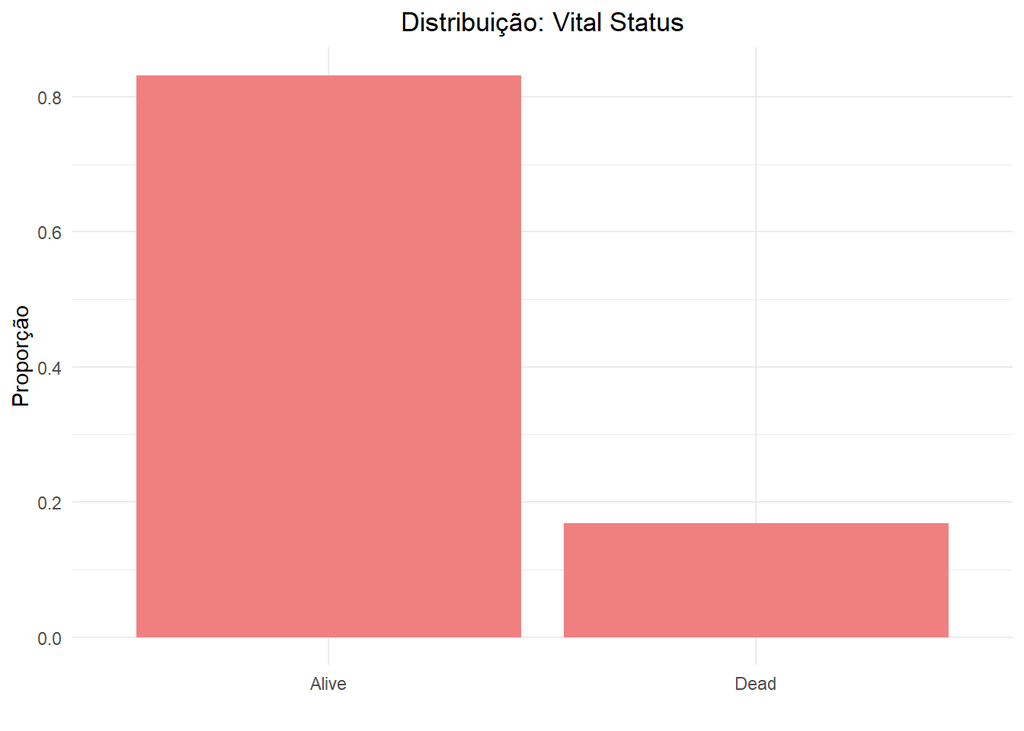

#### Classification of Tumor

A variável **classification_of_tumor** descreve o tipo de ocorrência tumoral registada em cada amostra. As classificações observadas incluem: *primary* (492 amostras), *metastasis* (21 amostras), *recurrence* (18 amostras) e *prior primary* (19 amostras).

```r
table(colData(rna_data)$classification_of_tumor)
```

```
##
##          metastasis        not reported             primary       Prior primary
##                  21                  20                 492                  19
##          recurrence  Subsequent Primary Synchronous primary
##                  18                   3                   4
```

Para esse efeito, foi criado um novo objeto, **tumor_class**, no qual se unificaram as referidas categorias menos representadas sob uma designação comum, como por exemplo *outros*. Esta abordagem visa mitigar os efeitos de viés associados ao desequilíbrio de classes, assegurando maior fiabilidade nas análises subsequentes.

```r
tumor_class <- metadata_subset %>%
  mutate(classification_of_tumor = ifelse(classification_of_tumor == "primary", "primary", "others"))
```

Em seguida, foram geradas tabelas de frequência com o intuito de visualizar a distribuição da variável **classification_of_tumor**, já com a nova categorização. Para complementar esta análise, foi construído um gráfico de barras utilizando a função **ggplot()**, representando visualmente a frequência das classificações tumorais. As amostras com valores omissos foram previamente excluídas, de forma a garantir a integridade da representação gráfica.

```r
table(tumor_class$classification_of_tumor) #Frequência Absoluta
```

```
##
##  others primary
##      85     492
```

```r
prop.table(table(tumor_class$classification_of_tumor)) * 100 #Frequência Relativa
```

```
##
##   others  primary
## 14.73137 85.26863
```

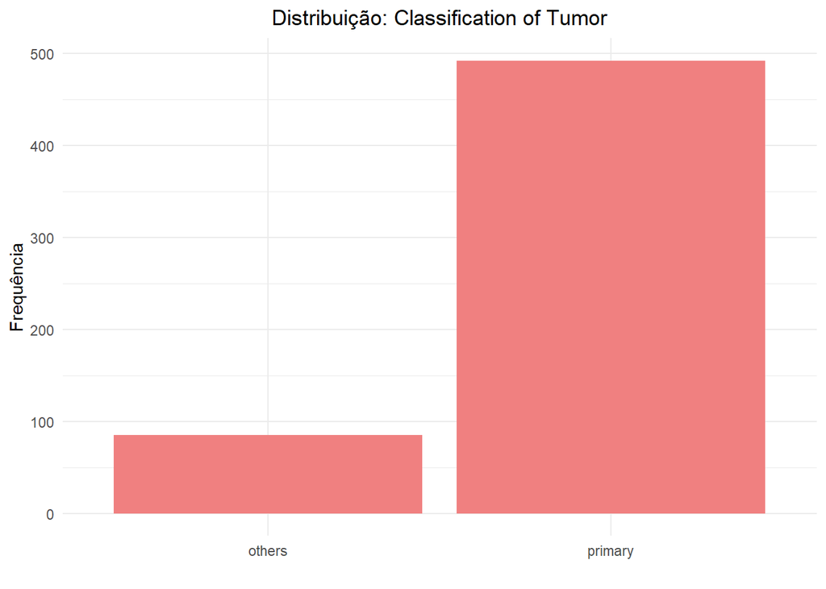

#### Tissue_type

A variável **tissue_type** apresenta duas categorias distintas: *normal* e *tumor*. A análise da sua distribuição revelou que aproximadamente 94% das amostras correspondem a tecidos tumorais, enquanto cerca de 6% dizem respeito a tecidos normais. Esta assimetria é expectável, tendo em conta que o principal foco do projeto TCGA consiste na caracterização molecular de tecidos neoplásicos.

Para ilustrar esta distribuição, foram construídas tabelas de frequência e um gráfico de barras recorrendo à função **ggplot()**, o qual confirma visualmente a predominância de amostras tumorais no conjunto de dados analisado.

```r
table(metadata_subset$tissue_type)
```

```
##
## Normal  Tumor
##     35    554
```

```r
prop.table(table(metadata_subset$tissue_type)) * 100
```

```
##
##    Normal     Tumor
##  5.942275 94.057725
```

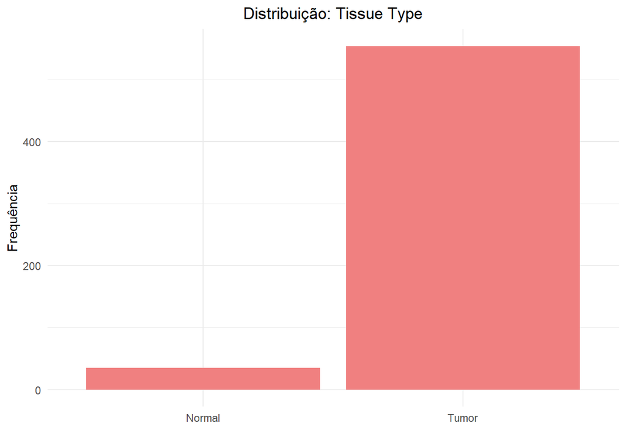

#### Primary_diagnosis

A variável **primary_diagnosis** apresenta uma ampla diversidade de diagnósticos associados ao cancro endometrial, refletindo a heterogeneidade clínica e histopatológica desta doença.

```r
table(colData(rna_data)$primary_diagnosis)
```

```
##
##             Adenocarcinoma with mixed subtypes
##                                              1
##                            Adenocarcinoma, NOS
##                                              6
##                        Adenoid basal carcinoma
##                                              1
##                      Basal cell carcinoma, NOS
##                                              2
##               Carcinoma, undifferentiated, NOS
##                                              2
##                 Clear cell adenocarcinoma, NOS
##                                              1
##                           Clear cell carcinoma
##                                              2
##               Endometrioid adenocarcinoma, NOS
##                                            404
## Endometrioid adenocarcinoma, secretory variant
##                                              2
##               Infiltrating duct carcinoma, NOS
##                                              1
##    Intraductal carcinoma, noninfiltrating, NOS
##                                              2
##   Malignant lymphoma, small B lymphocytic, NOS
##                                              1
##                                   Not Reported
##                                             22
##            Papillary serous cystadenocarcinoma
##                                              2
##                          Pheochromocytoma, NOS
##                                              1
##                 Serous cystadenocarcinoma, NOS
##                                            124
##             Serous surface papillary carcinoma
##                                              2
##                   Squamous cell carcinoma, NOS
##                                              1
```

A análise da frequência das categorias revelou que duas se destacam claramente: *Endometrioid adenocarcinoma, NOS*, com 404 ocorrências, e *Serous cystadenocarcinoma, NOS*, com 124 ocorrências. As restantes categorias apresentaram frequências individuais significativamente mais baixas.

Com o intuito de simplificar a análise e aumentar a robustez estatística das comparações entre grupos, foi criado um novo objeto, **diagnosis_filtered**, no qual apenas as duas categorias mais representadas foram mantidas de forma explícita. As demais foram agregadas sob o rótulo genérico *Others*. Esta abordagem permite minimizar os efeitos de variáveis com baixa representatividade e assegurar maior estabilidade nos testes estatísticos subsequentes.  
No entanto, duas categorias se destacam: *Endometrioid adenocarcinoma, NOS* com 404 ocorrências e *Serous cystadenocarcinoma, NOS* com 124 ocorrências.

```r
diagnosis_filtered <- metadata_subset %>%
  mutate(primary_diagnosis = ifelse(
    primary_diagnosis %in% c("Endometrioid adenocarcinoma, NOS", "Serous cystadenocarcinoma, NOS"),
    primary_diagnosis,
    "Others"
  ))
```

Após o reagrupamento das categorias da variável **primary_diagnosis**, foram geradas tabelas de frequência absoluta e relativa com o objetivo de visualizar a distribuição dos diferentes diagnósticos. Para complementar a análise, foi construído um gráfico de barras utilizando a função **ggplot()**, representando visualmente a predominância dos dois principais subtipos tumorais, com as restantes classificações incluídas na categoria *Others*.

A análise revelou que aproximadamente 68% das amostras correspondem a *Endometrioid adenocarcinoma, NOS*, enquanto cerca de 21% pertencem a *Serous cystadenocarcinoma, NOS*. Os 10% restantes distribuem-se pelas demais classificações, agora agrupadas sob o rótulo *Others*. Esta representação gráfica reforça a concentração da maioria das amostras em dois subtipos histológicos principais, evidenciando a sua relevância para análises comparativas no âmbito do presente estudo.

```r
table(diagnosis_filtered$primary_diagnosis)
```

```
##
## Endometrioid adenocarcinoma, NOS                           Others
##                              404                               61
##   Serous cystadenocarcinoma, NOS
##                              124
```

```r
prop.table(table(diagnosis_filtered$primary_diagnosis)) * 100
```

```
##
## Endometrioid adenocarcinoma, NOS                           Others
##                         68.59083                         10.35654
##   Serous cystadenocarcinoma, NOS
##                         21.05263
```

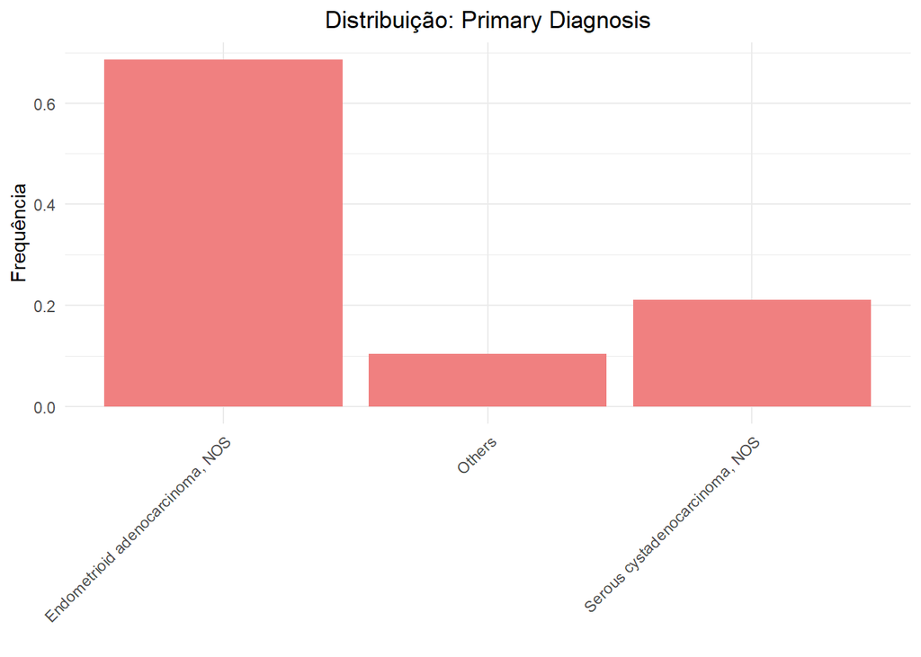

### Análise descritiva da variável numérica

#### Age_at_Index

A variável **age_at_index** corresponde à idade dos pacientes no momento do diagnóstico. Para caracterizar a sua distribuição, foram utilizadas medidas descritivas como a média, a mediana, os valores mínimo e máximo, bem como o desvio padrão, sendo previamente removidos os valores omissos para assegurar a fiabilidade da análise.

Os resultados indicam que a média de idade dos pacientes é de 64 anos, com uma mediana próxima deste valor. A idade mínima registada foi de 31 anos e a máxima de 89 anos, evidenciando uma ampla variação etária entre os indivíduos incluídos no estudo.

```r
summary(metadata_subset$age_at_index)
```

```
##    Min. 1st Qu.  Median    Mean 3rd Qu.    Max.    NA's
##   31.00   57.00   64.00   63.84   71.00   89.00      15
```

```r
sd(metadata_subset$age_at_index, na.rm = TRUE)
```

```
## [1] 11.15577
```

Posteriormente, foi elaborado um gráfico de densidade recorrendo à função **ggplot()**, com o intuito de representar a distribuição das idades na amostra de forma mais contínua e informativa. A análise deste gráfico revela uma maior concentração de pacientes na faixa etária entre os 50 e os 70 anos, o que reflete a prevalência deste intervalo etário no conjunto de dados. Esta observação está em consonância com a literatura, que aponta para uma maior incidência do cancro endometrial em mulheres pós-menopáusicas.

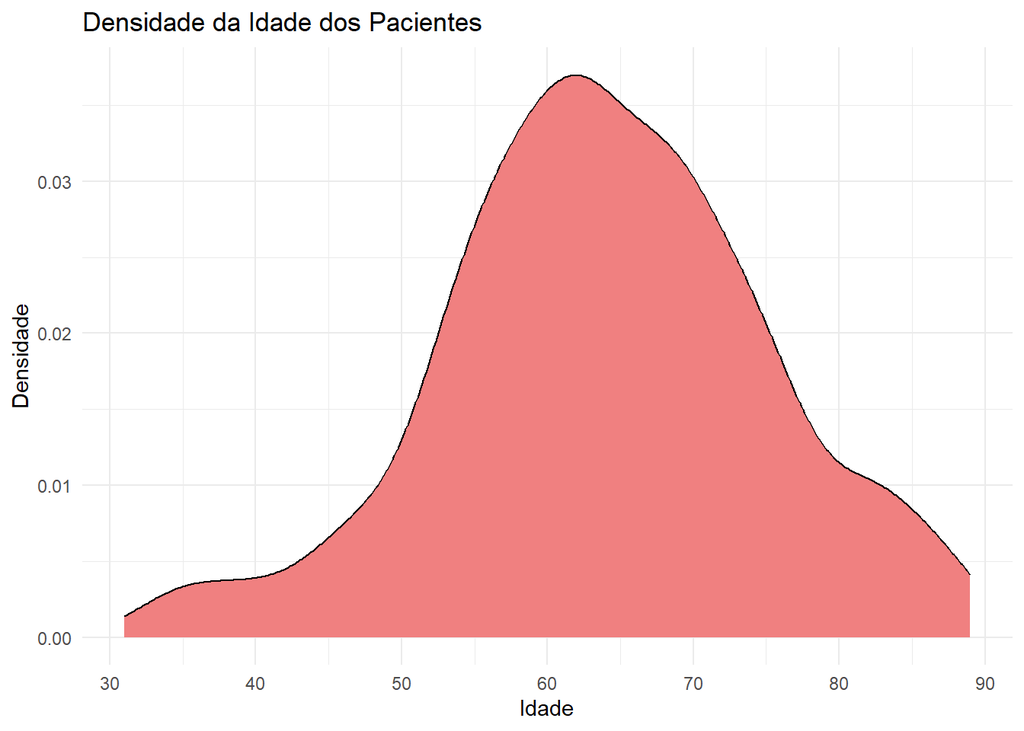

### Comparação entre categorias

#### Idade e status vital

Com o intuito de identificar possíveis associações entre a idade dos pacientes e o respetivo estado vital, foi realizada uma análise comparativa entre a variável **age_at_index** e **vital_status**. Esta comparação visa explorar se a sobrevivência dos indivíduos está relacionada com a sua idade à data do diagnóstico.

Para tal, foi construído um gráfico de **boxplot** recorrendo à função **ggplot()**, que permite visualizar a distribuição da idade em cada uma das categorias de estado vital (*Alive* e *Dead*). O gráfico revela uma tendência clara: os pacientes falecidos apresentam, em média, idades mais elevadas em comparação com os pacientes que se encontram vivos.

Esta tendência é corroborada pelas estatísticas descritivas geradas para cada grupo, as quais evidenciam uma diferença de aproximadamente cinco anos tanto na mediana como na média das idades entre os dois estados vitais. Tal padrão sugere que a idade pode desempenhar um papel relevante na sobrevivência dos pacientes com cancro endometrial, embora sejam necessárias análises mais aprofundadas para confirmar uma relação estatisticamente significativa.

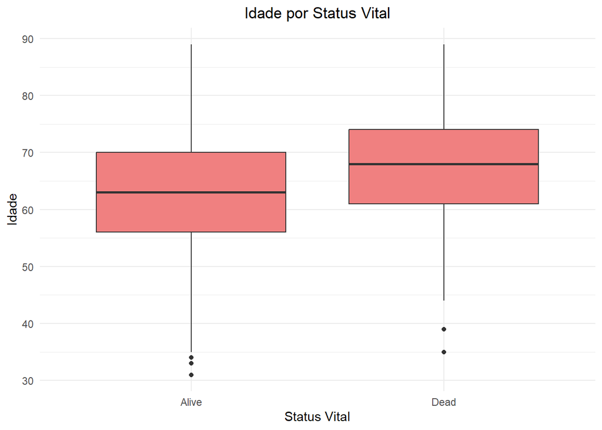

```
## $Alive
##    Min. 1st Qu.  Median    Mean 3rd Qu.    Max.    NA's
##   31.00   56.00   63.00   63.01   70.00   89.00       3
##
## $Dead
##    Min. 1st Qu.  Median    Mean 3rd Qu.    Max.
##   35.00   61.00   68.00   67.94   74.00   89.00
```

#### Idade e tipo de tecido

Foi realizada uma análise comparativa entre a idade dos pacientes (**age_at_index**) e o tipo de tecido (**tissue_type**) com o objetivo de identificar possíveis padrões etários associados à presença de tecido tumoral ou normal. Para esta análise, foi gerado um gráfico de **boxplot**, que permite observar a distribuição das idades nos dois grupos de tecido (*normal* e *tumor*).

A análise revela que os pacientes com tecido tumoral tendem a ser, em média, mais velhos em comparação com os pacientes com tecido normal. Este padrão é também corroborado pelas estatísticas descritivas, que indicam que tanto a mediana quanto a média das idades são mais elevadas no grupo de tecido tumoral, sugerindo uma maior prevalência de cancro em faixas etárias mais avançadas.

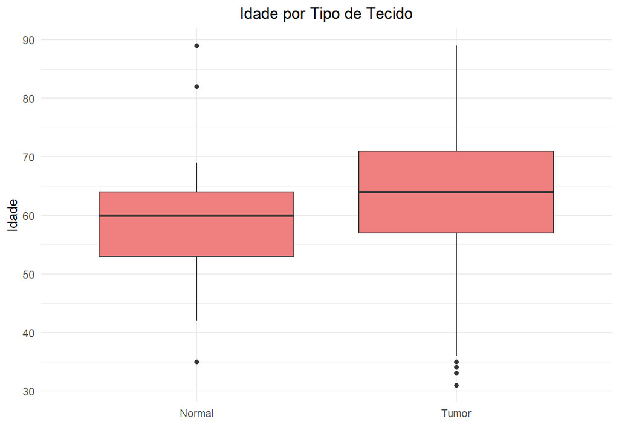

```
## $Normal
##    Min. 1st Qu.  Median    Mean 3rd Qu.    Max.    NA's
##   35.00   53.00   60.00   59.43   64.00   89.00      12
##
## $Tumor
##    Min. 1st Qu.  Median    Mean 3rd Qu.    Max.    NA's
##   31.00   57.00   64.00   64.03   71.00   89.00       3
```

#### Status vital por classificação do tumor

Foi realizada uma análise para investigar a distribuição do status vital (**vital_status**) em relação à classificação do tumor (**classification_of_tumor**), com o objetivo de identificar padrões associados à sobrevivência dos pacientes em diferentes tipos de tumor. Para esta análise, foi gerado um gráfico de barras empilhadas (utilizando **geom_bar**), que permite visualizar as proporções de pacientes vivos e falecidos em cada categoria de classificação do tumor.

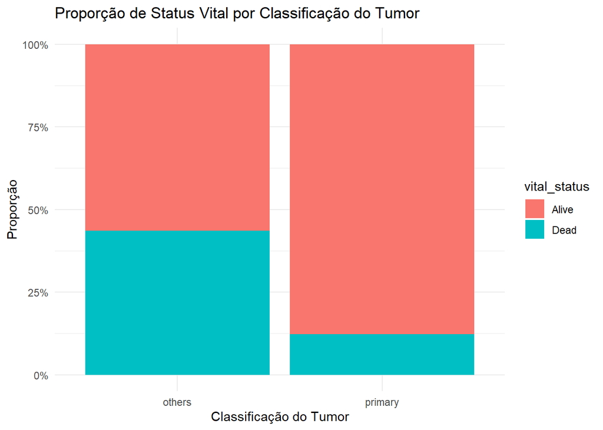

[output not shown]

### Testes de Hipótese

Para todos os testes de hipótese, foi considerado um valor de p < 0.05 como indicativo de significância estatística.

Para avaliar se a variável numérica **age_at_index** segue uma distribuição normal, foi aplicado o **teste de normalidade de Shapiro-Wilk**, onde:

- **H₀ (Hipótese nula):** Os dados seguem uma distribuição normal.
- **H₁ (Hipótese alternativa):** Os dados não seguem uma distribuição normal.

Este teste visa determinar se os dados se distribuem de forma normal, o que é uma suposição comum em muitos testes estatísticos paramétricos.

```r
shapiro.test(metadata_subset$age_at_index)
```

```
##
##  Shapiro-Wilk normality test
##
## data:  metadata_subset$age_at_index
## W = 0.9909, p-value = 0.001317
```

O teste resultou em um **valor de p** **inferior a 0.05**, o que leva à **rejeição da hipótese nula**. Este resultado indica que os dados de **age_at_index** não seguem uma distribuição normal, sugerindo a necessidade de utilizar métodos estatísticos não paramétricos para análises subsequentes.

#### Vital Status vs. Age at Index

Para avaliar se existe uma diferença significativa na **idade média** entre os pacientes **vivos** e **falecidos**, foi utilizado o **teste de Mann-Whitney (teste de soma de postos de Wilcoxon)**. Este teste foi escolhido devido à natureza **não paramétrica** dos dados, uma vez que já foi verificado que a variável **age_at_index** não segue uma distribuição normal.

As **hipóteses** formuladas para este teste foram:

- **H₀ (Hipótese nula):** A média da idade dos pacientes vivos é igual à média dos pacientes mortos.
- **H₁ (Hipótese alternativa):** A média da idade dos pacientes vivos é diferente da média dos pacientes mortos.

```r
wilcox.test(age_at_index ~ vital_status, data = metadata_subset)
```

```
##
##  Wilcoxon rank sum test with continuity correction
##
## data:  age_at_index by vital_status
## W = 17371, p-value = 0.0001077
## alternative hypothesis: true location shift is not equal to 0
```

O teste resultou em um **valor de p inferior a 0.05**, o que leva à **rejeição da hipótese nula**. Esse resultado indica que **a idade média dos pacientes vivos é significativamente diferente da idade média dos pacientes falecidos**, com uma diferença significativa nas idades entre os dois grupos.

#### Age at Index vs. Tissue Type

Para investigar se a **idade média** dos pacientes difere entre os grupos de **tecido normal** e **tecido tumoral**, foi utilizado o **teste de Mann-Whitney (teste de soma de postos de Wilcoxon)**, devido à natureza **não paramétrica** dos dados.

As **hipóteses** formuladas para este teste foram:

- **H₀ (Hipótese nula):** A média da idade dos pacientes é igual entre os tecidos normais e tumorais.
- **H₁ (Hipótese alternativa):** A média da idade dos pacientes difere entre os tecidos normais e tumorais.

```r
wilcox.test(age_at_index ~ tissue_type, data = metadata_subset)
```

```
##
##  Wilcoxon rank sum test with continuity correction
##
## data:  age_at_index by tissue_type
## W = 4741.5, p-value = 0.04064
## alternative hypothesis: true location shift is not equal to 0
```

O resultado do teste apresentou um **valor de p inferior a 0.05**, o que leva à **rejeição da hipótese nula**. Este resultado indica que **a média de idade dos pacientes com tecido tumoral é significativamente diferente da média de idade dos pacientes com tecido normal**.

#### Age at Index vs. Primary Diagnosis

Para avaliar se a **idade média** dos pacientes difere entre os **diferentes diagnósticos primários**, foi utilizado o **teste de Kruskal-Wallis**. Este teste foi escolhido devido à natureza **não paramétrica** da distribuição de idades e à variável categórica do diagnóstico primário.

As **hipóteses** formuladas para este teste foram:

- **H₀ (Hipótese nula):** A média da idade dos pacientes é igual entre todos os diagnósticos primários.
- **H₁ (Hipótese alternativa):** A média da idade dos pacientes difere entre pelo menos dois diagnósticos primários.

```r
kruskal.test(age_at_index ~ primary_diagnosis, data = diagnosis_filtered)
```

```
##
##  Kruskal-Wallis rank sum test
##
## data:  age_at_index by primary_diagnosis
## Kruskal-Wallis chi-squared = 31.465, df = 2, p-value = 1.47e-07
```

O teste resultou em um **valor de p inferior a 0.05**, o que leva à **rejeição da hipótese nula**. Esse resultado indica que **há uma diferença significativa na idade média** entre os pacientes com diferentes diagnósticos primários, sugerindo que a idade pode ser um fator associado ao tipo de diagnóstico primário.

#### Age at Index vs. Classification of Tumor

Para investigar se a **idade média** dos pacientes difere entre os **diferentes tipos de tumor**, foi aplicado o **teste de Kruskal-Wallis**. Este teste foi escolhido devido à variável de **classificação do tumor** ser categórica e à distribuição **não paramétrica** das idades.

As **hipóteses** formuladas para este teste foram:

- **H₀ (Hipótese nula):** Não há diferença significativa entre as idades e os diferentes tipos de tumor.
- **H₁ (Hipótese alternativa):** Pelo menos um tipo de tumor tem uma idade média diferente.

```r
kruskal.test(age_at_index ~ classification_of_tumor, data = tumor_class)
```

```
##
##  Kruskal-Wallis rank sum test
##
## data:  age_at_index by classification_of_tumor
## Kruskal-Wallis chi-squared = 0.44125, df = 1, p-value = 0.5065
```

O teste resultou em um **valor de p superior a 0.05**, o que leva à **não rejeição da hipótese nula**. Esse resultado indica que **não há diferença significativa na idade média** entre os diferentes tipos de tumor, sugerindo que a idade dos pacientes pode não estar associada de forma relevante ao tipo de tumor classificado.

#### Vital Status vs. Classification of Tumor

Para investigar a **associação** entre o **status vital (vital_status)** e a **classificação do tumor (classification_of_tumor)**, foi utilizado o **teste de qui-quadrado de Pearson**, com a **correção de continuidade de Yates**, para avaliar se as duas variáveis são independentes ou se existe uma associação significativa entre elas.

As **hipóteses** formuladas para este teste foram:

- **H₀ (Hipótese nula):** Não há associação entre o status vital e a classificação do tumor (as duas variáveis são independentes).
- **H₁ (Hipótese alternativa):** Existe uma associação significativa entre o status vital e a classificação do tumor.

```r
contingency_table <- table(tumor_class$vital_status, tumor_class$classification_of_tumor)
chisq.test(contingency_table)
```

```
##
##  Pearson's Chi-squared test with Yates' continuity correction
##
## data:  contingency_table
## X-squared = 48.669, df = 1, p-value = 3.031e-12
```

Com base nos resultados do teste, obteve-se um **valor de p inferior a 0.05**, o que leva à **rejeição da hipótese nula**. Este resultado indica que existe uma **associação significativa** entre o status vital dos pacientes e a classificação do tumor, sugerindo que o tipo de tumor pode estar relacionado ao desfecho clínico, ou seja, se o paciente está vivo ou falecido.

## Análise de expressão diferencial

```r
#Expressao diferencial

#vital_status x EA
# 1. Filtrar metadados: apenas Endometrioid adenocarcinoma, NOS e sem NAs
EA_meta <- metadata_subset %>%
  filter(primary_diagnosis == "Endometrioid adenocarcinoma, NOS" & !is.na(vital_status))

# 2. Garantir que os nomes das colunas em contagens correspondem às amostras
rna_EA <- rna_counts[, rownames(EA_meta)]

# 3. Filtrar genes: manter genes com contagem ≥ 20 em pelo menos 4 amostras
rna_filtered_EA <- rowSums(rna_EA >= 20) >= 4
rna_counts_filtrado <- rna_EA[rna_filtered_EA, ]

# 4. Criar objeto DESeq2
dds_EA <- DESeqDataSetFromMatrix(countData = rna_counts_filtrado,
                                 colData = EA_meta,
                                 design = ~ vital_status)

# 5. Transformar caracteres em fatores (se necessário)
dds_EA$vital_status <- factor(dds_EA$vital_status)

# 6. Executar DESeq2
dds_EA <- DESeq(dds_EA)
```

```r
# 7. Resultados: comparar Dead vs Alive (Dead - referência por padrão)
res_EA <- results(dds_EA, contrast = c("vital_status", "Dead", "Alive"))

# 8. Ver resumo e visualizar top genes
summary(res_EA)
```

```
##
## out of 27326 with nonzero total read count
## adjusted p-value < 0.1
## LFC > 0 (up)       : 2781, 10%
## LFC < 0 (down)     : 1550, 5.7%
## outliers [1]       : 0, 0%
## low counts [2]     : 0, 0%
## (mean count < 0)
## [1] see 'cooksCutoff' argument of ?results
## [2] see 'independentFiltering' argument of ?results
```

```r
sum(res_EA$padj < 0.05, na.rm = TRUE)
```

```
## [1] 2956
```

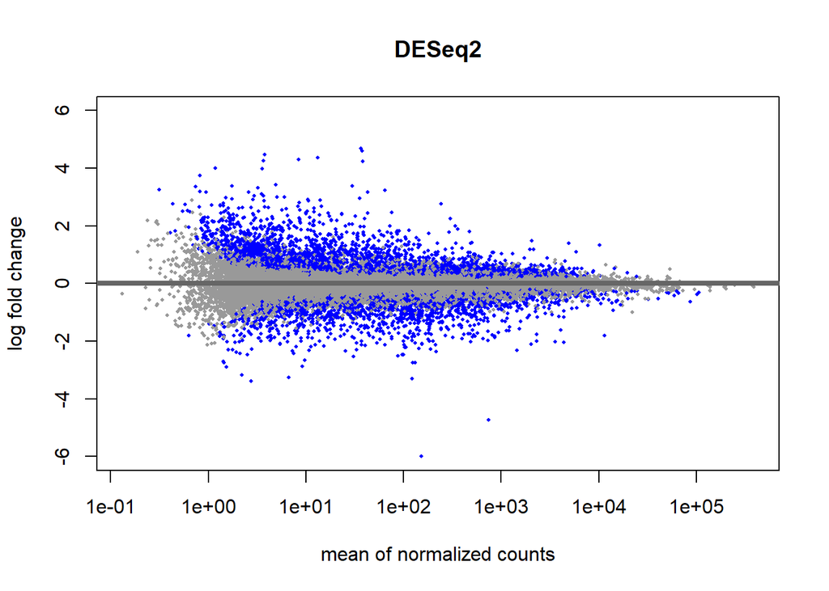

Foram considerados significativos os genes com padj < 0.05 e |log2FoldChange| > 1. A análise identificou 1180 genes diferencialmente expressos entre os pacientes vivos e mortos neste subtipo tumoral. Destes, 700 genes apresentaram regulação positiva (sobre-expressão) e 480 genes apresentaram regulação negativa (sub-expressão) nos pacientes com Endometrioid adenocarcinoma falecidos.

```r
res_df <- as.data.frame(res_EA)
res_df$gene <- rownames(res_EA)
res_df$significant <- ifelse(res_df$padj < 0.05 & abs(res_df$log2FoldChange) > 1, "Significativo", "Não significativo")


# Transformar o objeto de resultados em um data frame
res_df_EA <- as.data.frame(res_EA)
res_df_EA$gene <- rownames(res_df_EA)

# Criar a coluna 'regulation' com base em critérios de significância
res_df_EA <- res_df %>%
  mutate(regulation = case_when(
    padj < 0.05 & log2FoldChange > 1 ~ "Up",
    padj < 0.05 & log2FoldChange < -1 ~ "Down",
    TRUE ~ "Not Sig"
  ))
# Ver distribuição dos genes por tipo de regulação
table(res_df_EA$regulation)
```

```
##
##    Down Not Sig      Up
##     480   26146     700
```

```r
# Selecionar os genes mais significativos
top_genes_EA <- res_df_EA %>%
  filter(padj < 0.05) %>%
  arrange(desc(abs(log2FoldChange))) %>%
  slice_head(n = 20)
```

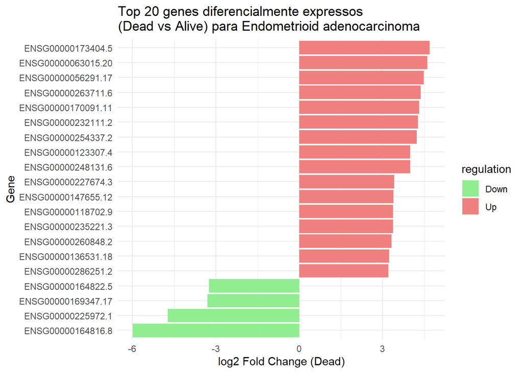

```
##                      baseMean log2FoldChange     lfcSE       stat       pvalue
## ENSG00000164816.8  153.057988      -5.994032 1.1518688  -5.203746 1.953109e-07
## ENSG00000225972.1  747.388076      -4.736431 0.4529998 -10.455701 1.379741e-25
## ENSG00000173404.5   36.452742       4.690211 0.4507906  10.404411 2.367154e-25
## ENSG00000063015.20  37.487139       4.604815 0.3630376  12.684125 7.241797e-37
## ENSG00000056291.17   3.775929       4.475269 0.5379470   8.319165 8.858537e-17
## ENSG00000263711.6   13.127776       4.363162 0.6769348   6.445469 1.152435e-10
##                            padj               gene   significant regulation
## ENSG00000164816.8  2.541460e-05  ENSG00000164816.8 Significativo       Down
## ENSG00000225972.1  1.256760e-21  ENSG00000225972.1 Significativo       Down
## ENSG00000173404.5  1.617121e-21  ENSG00000173404.5 Significativo         Up
## ENSG00000063015.20 1.978893e-32 ENSG00000063015.20 Significativo         Up
## ENSG00000056291.17 1.729060e-13 ENSG00000056291.17 Significativo         Up
## ENSG00000263711.6  4.700215e-08  ENSG00000263711.6 Significativo         Up
##                                                      gene_name
## ENSG00000164816.8                             defensin alpha 5
## ENSG00000225972.1                         MT-ND1 pseudogene 23
## ENSG00000173404.5             INSM transcriptional repressor 1
## ENSG00000063015.20                   seizure related 6 homolog
## ENSG00000056291.17                  neuropeptide FF receptor 2
## ENSG00000263711.6  long intergenic non-protein coding RNA 2864
```

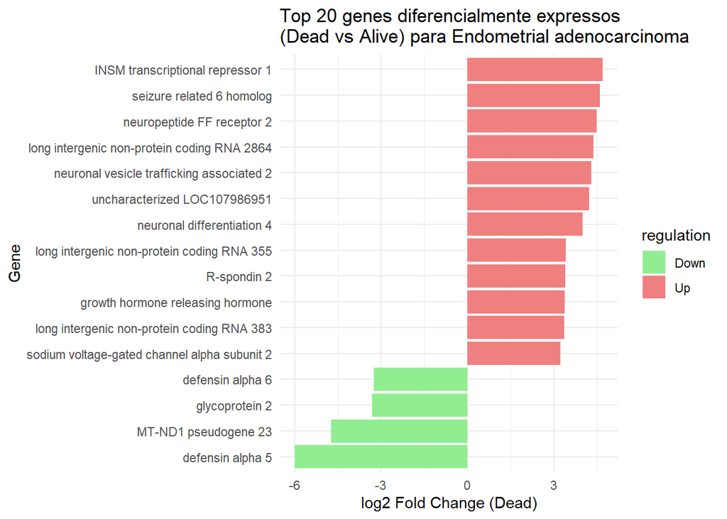

```r
# Mapear os IDs ENSEMBL para o nome completo do gene (GENENAME) para top_genes_EA
ensembl_ids_EA <- top_genes_EA$gene

# Limpar as versões dos IDs ENSEMBL
clean_ids_EA <- sub("\\..*", "", ensembl_ids_EA)

# Mapear os IDs ENSEMBL para o nome completo do gene (GENENAME)
gene_names_EA <- mapIds(org.Hs.eg.db, keys = clean_ids_EA, column = "GENENAME", keytype = "ENSEMBL", multiVals = "first")


# Adicionar os nomes dos genes ao dataframe
top_genes_EA$gene_name <- gene_names_EA
```

```r
#vital_status x SC

# 1. Filtrar metadados: apenas Endometrioid adenocarcinoma, NOS e sem NAs
SC_meta <- metadata_subset %>%
  filter(primary_diagnosis == "Serous cystadenocarcinoma, NOS" & !is.na(vital_status))

# 2. Garantir que os nomes das colunas em contagens correspondem às amostras
rna_SC <- rna_counts[, rownames(SC_meta)]

# 3. Filtrar genes: manter genes com contagem ≥ 20 em pelo menos 4 amostras
rna_filtered_SC <- rowSums(rna_SC >= 20) >= 4
rna_counts_filtrado_SC <- rna_SC[rna_filtered_SC, ]

# 4. Criar objeto DESeq2
dds_SC <- DESeqDataSetFromMatrix(countData = rna_counts_filtrado_SC,
                                 colData = SC_meta,
                                 design = ~ vital_status)

# 5. Transformar caracteres em fatores (se necessário)
dds_SC$vital_status <- factor(dds_SC$vital_status)

# 6. Executar DESeq2
dds_SC <- DESeq(dds_SC)

# 7. Resultados: comparar Dead vs Alive (Dead - referência por padrão)
res_SC <- results(dds_SC, contrast = c("vital_status", "Dead", "Alive"))

# 8. Ver resumo e visualizar top genes
summary(res_SC)
```

```
##
## out of 27553 with nonzero total read count
## adjusted p-value < 0.1
## LFC > 0 (up)       : 224, 0.81%
## LFC < 0 (down)     : 393, 1.4%
## outliers [1]       : 0, 0%
## low counts [2]     : 0, 0%
## (mean count < 0)
## [1] see 'cooksCutoff' argument of ?results
## [2] see 'independentFiltering' argument of ?results
```

```r
head(res_SC[order(res_SC$pvalue), ])
```

```
## log2 fold change (MLE): vital_status Dead vs Alive
## Wald test p-value: vital status Dead vs Alive
## DataFrame with 6 rows and 6 columns
##                     baseMean log2FoldChange     lfcSE      stat      pvalue
##                    <numeric>      <numeric> <numeric> <numeric>   <numeric>
## ENSG00000112818.10   10.5239        3.10298  0.426634   7.27317 3.51147e-13
## ENSG00000171747.9    91.1820        2.62437  0.377539   6.95126 3.62046e-12
## ENSG00000212232.1    78.9324       -2.92906  0.431714  -6.78472 1.16308e-11
## ENSG00000056291.17   39.6851       -4.04841  0.615821  -6.57399 4.89830e-11
## ENSG00000120210.8    12.8069       -3.45258  0.538467  -6.41187 1.43746e-10
## ENSG00000131095.13   68.2043        2.27848  0.367371   6.20212 5.57083e-10
##                           padj
##                      <numeric>
## ENSG00000112818.10 9.67515e-09
## ENSG00000171747.9  4.98772e-08
## ENSG00000212232.1  1.06821e-07
## ENSG00000056291.17 3.37407e-07
## ENSG00000120210.8  7.92128e-07
## ENSG00000131095.13 2.55822e-06
```

```r
sum(res_SC$padj < 0.05, na.rm = TRUE)
```

```
## [1] 298
```

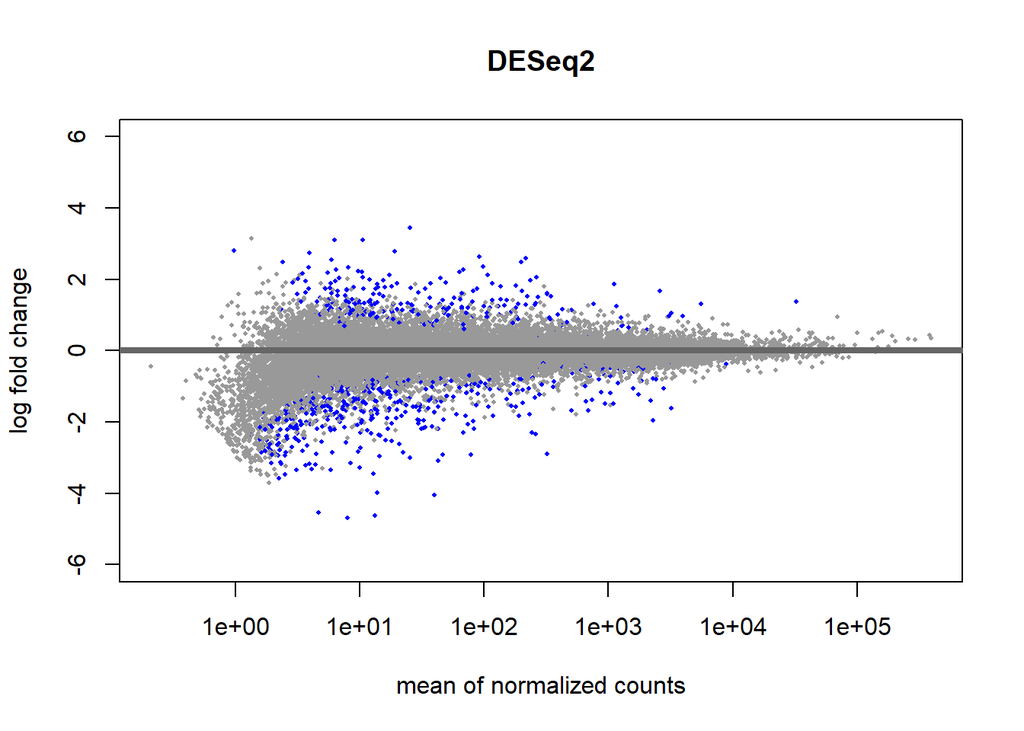

```r
res_df_SC <- as.data.frame(res_SC)
res_df_SC$gene <- rownames(res_SC)
res_df_SC$significant <- ifelse(res_df_SC$padj < 0.05 & abs(res_df_SC$log2FoldChange) > 1, "Significativo", "Não significativo")


#Visualizar expressão dos top20 genes em vital_status vs SC
# Transformar o objeto de resultados em um data frame
res_df_SC <- as.data.frame(res_SC)
res_df_SC$gene <- rownames(res_df_SC)

# Criar a coluna 'regulation' com base em critérios de significância
res_df_SC <- res_df_SC %>%
  mutate(regulation = case_when(
    padj < 0.05 & log2FoldChange > 1 ~ "Up",
    padj < 0.05 & log2FoldChange < -1 ~ "Down",
    TRUE ~ "Not Sig"
  ))

# Ver distribuição dos genes por tipo de regulação
table(res_df_SC$regulation)
```

```
##
##    Down Not Sig      Up
##     159   27290     104
```

```r
# Selecionar os genes mais significativos
top_genes_SC <- res_df_SC %>%
  filter(padj < 0.05) %>%
  arrange(desc(abs(log2FoldChange))) %>%
  slice_head(n = 20)
```

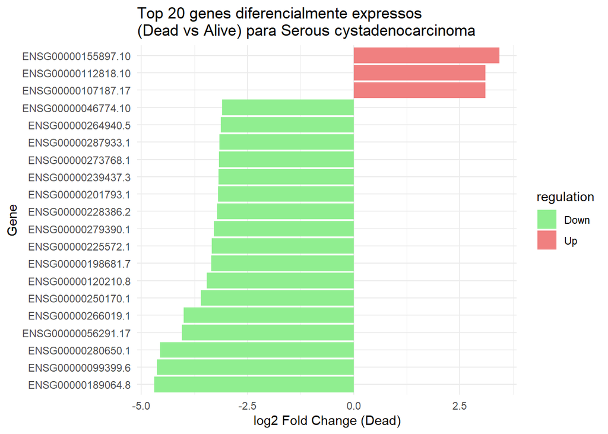

```
##                     baseMean log2FoldChange     lfcSE      stat       pvalue
## ENSG00000189064.8   7.964718      -4.695626 1.0391586 -4.518681 6.222620e-06
## ENSG00000099399.6  13.351495      -4.626913 0.8157231 -5.672161 1.410071e-08
## ENSG00000280650.1   4.671283      -4.550223 1.0449052 -4.354675 1.332644e-05
## ENSG00000056291.17 39.685060      -4.048407 0.6158214 -6.573995 4.898296e-11
## ENSG00000266019.1  13.749873      -3.995916 0.7754168 -5.153249 2.560122e-07
## ENSG00000250170.1   2.257288      -3.591421 1.0050901 -3.573233 3.526011e-04
##                            padj               gene regulation
## ENSG00000189064.8  3.234941e-03  ENSG00000189064.8       Down
## ENSG00000099399.6  4.316855e-05  ENSG00000099399.6       Down
## ENSG00000280650.1  6.019398e-03  ENSG00000280650.1       Down
## ENSG00000056291.17 3.374068e-07 ENSG00000056291.17       Down
## ENSG00000266019.1  3.823261e-04  ENSG00000266019.1       Down
## ENSG00000250170.1  4.151803e-02  ENSG00000250170.1       Down
##                                       gene_name
## ENSG00000189064.8                  G antigen 2E
## ENSG00000099399.6         MAGE family member B2
## ENSG00000280650.1  KCNIP4 intronic transcript 1
## ENSG00000056291.17   neuropeptide FF receptor 2
## ENSG00000266019.1                 microRNA 3609
## ENSG00000250170.1   RASA2 intronic transcript 1
```

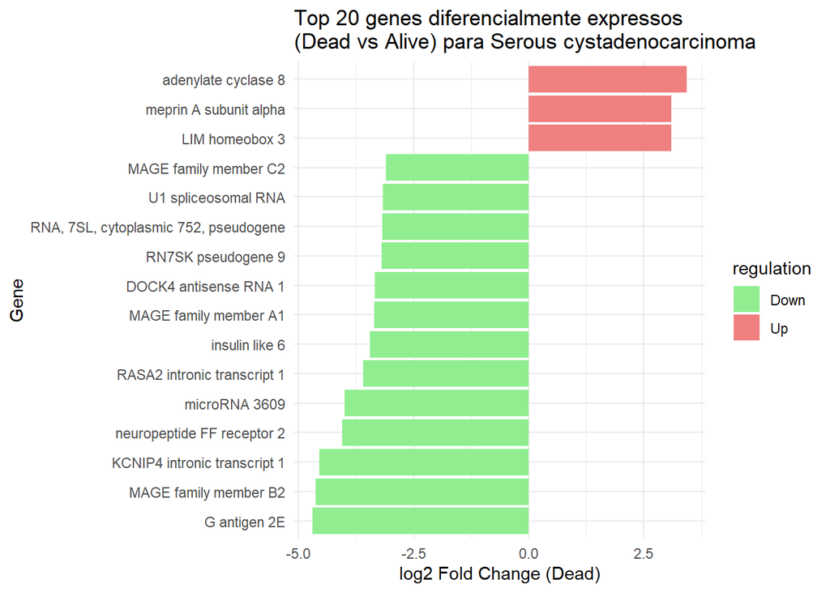

### Análise de enriquecimento

Com o objetivo de interpretar funcionalmente os genes diferencialmente expressos entre pacientes vivos e mortos, foi realizada uma análise de enriquecimento baseada na ontologia Gene Ontology. O primeiro passo consistiu na filtragem dos genes significativamente expressos, selecionando apenas aqueles com valor de padj inferior a 0.05 e variação absoluta de expressão (|log2FoldChange|) superior a 1, de forma a garantir a relevância biológica dos genes incluídos. Em seguida, os identificadores genéticos em formato ENSEMBL foram convertidos para ENTREZ IDs, conforme requerido pelas ferramentas de enriquecimento funcional. Esta conversão foi realizada com recurso à base de dados org.Hs.eg.db, tendo sido removidos os genes que não puderam ser mapeados. Posteriormente, foi aplicada a função enrichGO() do pacote clusterProfiler para identificar os termos de processos biológicos sobre-representados entre os genes selecionados.

```
## # A tibble: 5 × 6
## # Groups:   ID [5]
##   ID         Description                    mean_log2FC sd_log2FC Count p.adjust
##   <chr>      <chr>                                <dbl>     <dbl> <int>    <dbl>
## 1 GO:0042391 regulation of membrane potent…       0.849      1.60    41  4.29e-5
## 2 GO:0006959 humoral immune response             -1.26       1.61    27  2.15e-3
## 3 GO:0098742 cell-cell adhesion via plasma…       0.231      1.75    26  1.14e-3
## 4 GO:0030198 extracellular matrix organiza…      -0.495      1.44    24  3.98e-2
## 5 GO:0043062 extracellular structure organ…      -0.495      1.44    24  4.05e-2
```

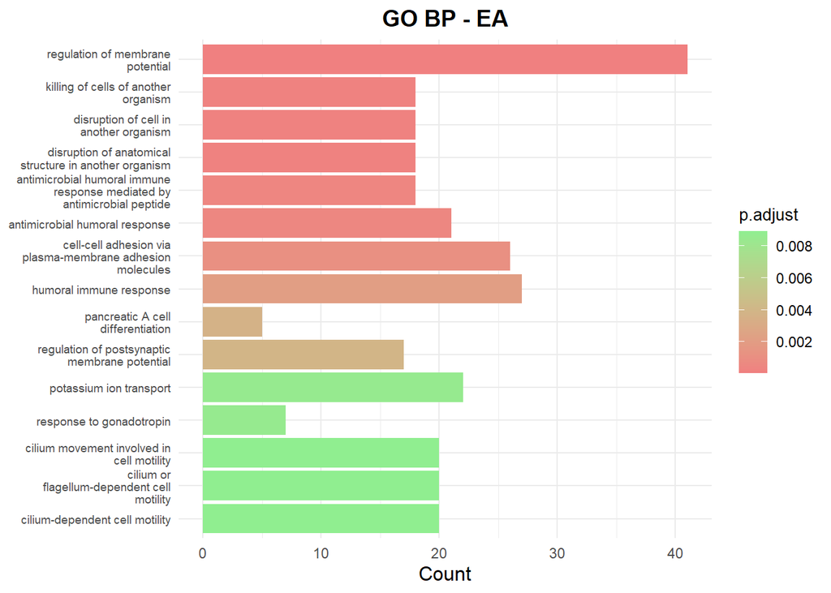

```r
#Análise de Enriquecimento para EA

# Filtrar genes significativos (p < 0.05 e |log2FC| > 1)
EA_genes_sig <- res_df_EA %>% filter(padj < 0.05 & abs(log2FoldChange) > 1)
EA_genes_ids <- sub("\\..*", "", EA_genes_sig$gene)

# Converter ENSEMBL para ENTREZ ID
EA_entrez_ids <- mapIds(org.Hs.eg.db,
                        keys = EA_genes_ids,
                        column = "ENTREZID",
                        keytype = "ENSEMBL",
                        multiVals = "first")

# Remover NAs
EA_entrez_ids <- na.omit(EA_entrez_ids)

# Enriquecimento GO - Biological Process
EA_GO_enrich <- enrichGO(gene = EA_entrez_ids,
                         OrgDb = org.Hs.eg.db,
                         keyType = "ENTREZID",
                         ont = "BP",
                         pAdjustMethod = "BH",
                         qvalueCutoff = 0.05,
                         readable = TRUE)
```

- Resposta imune humoral (GO:0006959), relacionada com a produção de anticorpos mediados por linfócitos B;
- Citotoxicidade celular (GO:0031640), que envolve a capacidade das células do sistema imune, como linfócitos T e células NK, destruírem células-alvo;
- Atividade antimicrobiana (GO:0061844), associada à expressão de genes com propriedades defensivas contra patógenos;
- Adesão célula-célula (GO:0098609), um processo fundamental para a manutenção da arquitetura tecidular e inibição da invasão tumoral;
- Regulação do potencial de membrana (GO:0042391), implicada na excitabilidade celular e nos mecanismos de sinalização intercelular.

Em conjunto, os resultados apontam para a existência de alterações moleculares sistemáticas nos pacientes falecidos com subtipo EA, envolvendo componentes chave do sistema imune, da homeostase celular e da integridade estrutural dos tecidos. Estes processos, quando desregulados, podem contribuir para a progressão tumoral, evasão imune e, consequentemente, para um pior desfecho clínico.

```
## # A tibble: 5 × 6
## # Groups:   ID [5]
##   ID         Description                    mean_log2FC sd_log2FC Count p.adjust
##   <chr>      <chr>                                <dbl>     <dbl> <int>    <dbl>
## 1 GO:0006334 nucleosome assembly                 -1.75      0.323    15 1.93e-10
## 2 GO:0034728 nucleosome organization             -1.75      0.323    15 9.64e-10
## 3 GO:0065004 protein-DNA complex assembly        -1.75      0.323    15 1.56e- 6
## 4 GO:0071824 protein-DNA complex organizat…      -1.75      0.323    15 3.43e- 6
## 5 GO:0019730 antimicrobial humoral response      -0.303     2.15      9 4.51e- 3
```

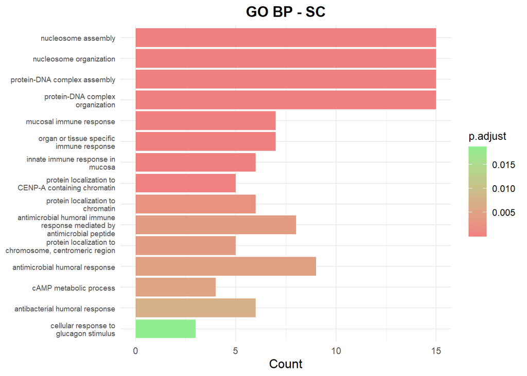

```r
#Enriquecimento para SC

SC_genes_sig <- res_df_SC %>% filter(padj < 0.05 & abs(log2FoldChange) > 1)
SC_genes_ids <- sub("\\..*", "", SC_genes_sig$gene)

SC_entrez_ids <- mapIds(org.Hs.eg.db,
                        keys = SC_genes_ids,
                        column = "ENTREZID",
                        keytype = "ENSEMBL",
                        multiVals = "first")

SC_entrez_ids <- na.omit(SC_entrez_ids)

SC_GO_enrich <- enrichGO(gene = SC_entrez_ids,
                         OrgDb = org.Hs.eg.db,
                         keyType = "ENTREZID",
                         ont = "BP",
                         pAdjustMethod = "BH",
                         qvalueCutoff = 0.05,
                         readable = TRUE)
```

Para o subtipo Serous cystadenocarcinoma (SC), foi igualmente realizada uma análise de enriquecimento funcional com base em termos da ontologia GO, considerando os genes diferencialmente expressos entre pacientes vivos e mortos (critério: padj < 0.05 e |log2FoldChange| > 1). A análise permitiu identificar múltiplos processos biológicos significativamente enriquecidos, refletindo alterações moleculares específicas associadas ao estado vital neste subtipo mais agressivo de cancro endometrial. Entre os principais processos destacam-se:

Notavelmente, os processos mais significativamente enriquecidos envolvem alterações na arquitetura da cromatina, como a montagem e remodelação de nucleossomas, sugerindo que alterações epigenéticas desempenham um papel central na regulação da expressão génica neste subtipo. Estes resultados estão em consonância com a natureza altamente agressiva do Serous cystadenocarcinoma, frequentemente associada a instabilidade genómica e alterações epigenéticas profundas.

Além disso, a presença de vários termos imunitários enriquecidos reforça a ideia de que o microambiente tumoral imune pode desempenhar um papel importante na evolução da doença. A desregulação de genes associados à imunidade humoral e à resposta mucosa pode refletir uma ativação compensatória do sistema imune ou, inversamente, uma evasão imune por parte das células tumorais.

## Referências Bibliográficas

1. Tomczak, K., Czerwińska, P. & Wiznerowicz, M. The Cancer Genome Atlas (TCGA): An immeasurable source of knowledge. Wspolczesna Onkologia vol. 1A A68–A77 Preprint at https://doi.org/10.5114/wo.2014.47136 (2015).
2. Liu, J. et al. An Integrated TCGA Pan-Cancer Clinical Data Resource to Drive High-Quality Survival Outcome Analytics. Cell 173, 400-416.e11 (2018).
3. Abu-Rustum, N. et al. Uterine Neoplasms, Version 1.2023. JNCCN Journal of the National Comprehensive Cancer Network 21, 181–209 (2023).
4. Bray, F. et al. Global cancer statistics 2022: GLOBOCAN estimates of incidence and mortality worldwide for 36 cancers in 185 countries. CA Cancer J Clin 74, 229–263 (2024).
5. Gullo, G. et al. Fertility-Sparing Strategies for Early-Stage Endometrial Cancer: Stepping towards Precision Medicine Based on the Molecular Fingerprint. International Journal of Molecular Sciences vol. 24 Preprint at https://doi.org/10.3390/ijms24010811 (2023).
6. Aimagambetova, G. et al. Contemporary Fertility-Sparing Management Options of Early Stage Endometrioid Endometrial Cancer in Young Nulliparous Patients. J Clin Med 11, (2021).